# OSAR em Belo Jardim (PE)

## **INTRODUÇÃO**

Neste projeto encontram-se as bases de dados e códigos computacionais utilizados numa apresentação feita pelo Observatório de Saneamento e Meio Ambiente do Recife (OSAR) sobre os dados de saneamento em Belo Jardim, município do Agreste pernambucano, no evento **Digitologias**. Todo o trabalho foi feito em [linguagem R](https://openastrolabium.wordpress.com/2017/05/24/introducao-ao-r/). As bases de dados originais, assim como os códigos para gerareste documento se encontram em [nosso repositório](https://github.com/observatoriosar).tratra

Os indicadores utilizados na análise foram identificados na base de dados do Sistema de Informação Sobre Saneamento (SNIS, 2015). Segue abaixo os indicadores e seus respectivos códigos:

| **Indicador** | **Código no SNIS** |
| --- | --- |
| População total atendida com abastecimento de água (Habitantes) | AG001 |
| Consumo médio per capta de água (l/hab./dia) | IN022 |
| Índice de Coleta de esgoto | IN056 |
| Índice de tratamento de esgoto (percentual) | IN016 |
| Volume de esgotos coletado (1.000 m³/ano) | ES005 |

De forma exploratória, discutimos com os participantes do evento cada indicador, observando sua variação ao longo do tempo e questionando os fatores que os explicavam. Nosso objetivo foi apresentar os dados sobre a situação sanitária do município e compreender o comportamento dos dados ao longo do tempo.

#### **Iniciando o R**

```r
# instalar pacotes (quando necessario)
# install.packages(c("readxl", "ggmap", "ggplot2"))

# carregar pacotes
library(readxl); library(ggmap); library(ggplot2)
```

#### **Definir padrão para gráficos**

```r
# tema para grafico
theme_arretado<- function (base_size = 12, base_family = "") {
  theme_minimal(base_size = base_size, base_family = base_family) %+replace%
    theme(axis.text.x = element_text(colour= "black",size=11,hjust=.5,vjust=.5,face="plain"),
          axis.text.y = element_text(colour="black",size=11,angle=0,hjust=1,vjust=0,face="plain"),
          axis.title.x = element_text(colour="black",size=12,angle=0,hjust=.5,vjust=0,face="plain"),
          axis.title.y = element_text(colour="black",size=12,angle=90,hjust=0.5,vjust=0.6,face="plain"),
          title = element_text(colour="black",size=12,angle=0,hjust=.5,vjust=.5,face="plain"),
          panel.grid.major = element_line(colour = grey(0.85)),
          panel.grid.minor = element_line(colour = grey(1)),
          legend.key.size = unit(9, "mm"),
          legend.text = element_text(size = 9, hjust = 3, vjust = 3),
          legend.title = element_text(size = 9),
          axis.line = element_line(size = 1, colour = "grey70"))
}
```

## **ANÁLISE**

No período 2004-2015 houve expansão do serviço de abastecimento de água que passou a atender quase toda a população do município. Entretanto, observando o Consumo médio per capta de água, verificou-se uma redução drástica no consumo de água. Em discussão, tomamos conhecimento de que seca foi um fator determinante para redução do consumo de água no município.

```r
# importar dados
munic_PE_1_ <-  read_excel("Dados/belo jardim total.xlsx")
```

### **1. Abastecimento de Água**

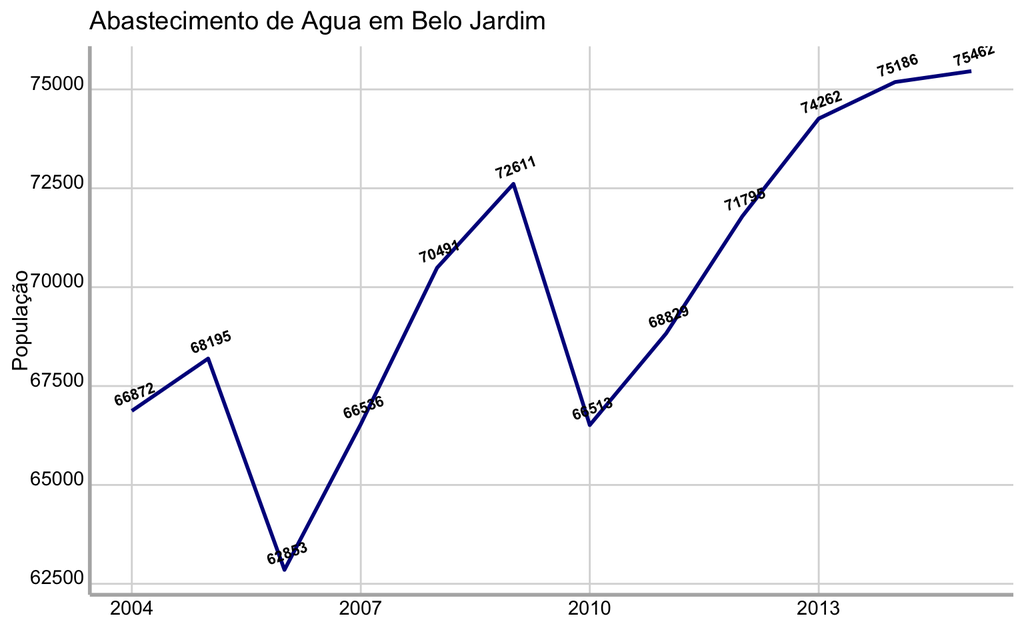

```r
belo1 <- ggplot(data = munic_PE_1_)+
  geom_line(aes(x = `Ano de Referência`,
                y = `AG001 - População total atendida com abastecimento de água (Habitantes)`,
                group =1),
                size = 1,
                colour = "darkblue")+

  geom_text(aes( x = `Ano de Referência`,
                 y = `AG001 - População total atendida com abastecimento de água (Habitantes)`,
                 angle = 20 ,
                 vjust = -0.9,
                 hjust = 0.3,
                 fontface = "bold"),
                 label = munic_PE_1_$`AG001 - População total atendida com abastecimento de água (Habitantes)`,
                 size = 3)+
  labs(x = "",
       title = "Abastecimento de Agua em Belo Jardim",
       y = "População")+
  theme_arretado()

# visualizar grafico
print(belo1)
```

### **2. Consumo Médio de Água**

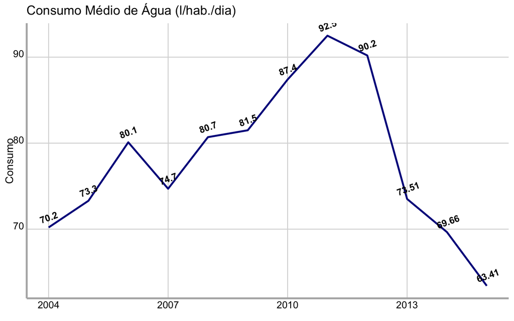

```r
belo2 <- ggplot(data = munic_PE_1_,
                aes(x = `Ano de Referência`,
                    y = munic_PE_1_$`IN022 - Consumo médio percapita de água (l/hab./dia)`,
                    group =1))+
  geom_line(size = 1,
            colour = "darkblue")+
  geom_text(aes( angle = 20 ,
                 vjust = -0.9,
                 hjust = 0.3,
                 fontface = "bold"),
                 label = munic_PE_1_$`IN022 - Consumo médio percapita de água (l/hab./dia)`,
                 size = 3.7)+
  labs(x = "",
       title = "Consumo Médio de Água (l/hab./dia)",
       y = "Consumo")+
  theme_arretado()
belo2
```

2018-01-03